# Walking Around the 5Cs

December 10, 2025

Adrián Blanco

## Background Information

- My favorite thing to do on weekend nights this semester has been walking around and seeing people.
- The Saturday night before this project was due I had a really fun night where I ran into at least 8 of my close friends.
- My question: “What is the probability that I run into ‘X’ number of friends on a given night of walking around the 5Cs?”

## General Overview

- I walk for 3 hours (180 minutes).
- I pass a certain number of people every minute.
- Each of those people lie somewhere on the scale between my closest friend at the 5Cs and the most complete stranger I could come across at the 5Cs.

## How I Created the Model

- I created a distribution of the number of people I pass each minute.
- The rate for this distribution is 1/4, which means I would see an average of 4 people each minute.

```r
set.seed(14)
exprate <- 0.25
data.frame(n = map_dbl(1:180, function(x){
    floor(rexp(1, exprate))}))
```

```
     n
1    2
2    1
3    1
4    0
5    1
6    4
7    0
8    2
9    4
10   1
11   0
12   5
13   0
14   1
```

[output cut: 166 more lines]

## How I Created the Model

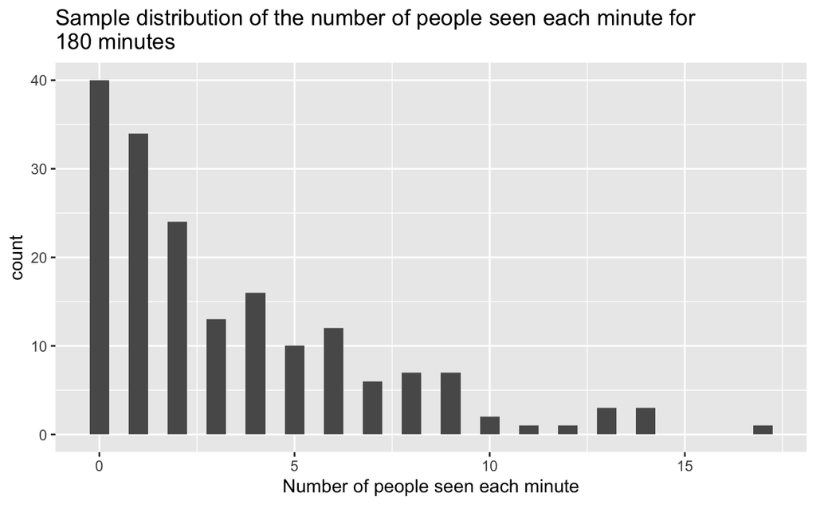

This plot shows how many times I see a certain number of people each minute if I walk around for 180 minutes.

## How I Created the Model

- Who is in these groups of people that I pass each minute?
- Assign each person in each group a number between 1 and 6000.

```r
#pass random people walking around the 5Cs
start_walking_for <- function(number_of_minutes, how_close){
  people_passed <- map_dbl(1:number_of_minutes, function(x){
    floor(rexp(1, exprate))})
      #vector of the number of people I pass every minute
  list_of_people <- map(people_passed, function(x){
    round(runif(x, min = 1, max = 6000))})
  vector_of_people <- unlist(list_of_people)
    #Time steps do not matter,
    #so it doesn't matter if I see someone in minute 1 or minute 156.
  sum(vector_of_people <= how_close)
    #How many times do I see someone who is my close friend?
}
```

## Results

- Run this simulation 5000 times to see the likelihood I run into 8 of my friends is.

```r
walking_time <- 180
friends <- 15
nights <- 5000

data.frame(friends_seen =
             map_dbl(1:nights, ~start_walking_for(walking_time, friends)))
```

```
     friends_seen
1               3
2               1
3               1
4               2
5               2
6               1
7               5
8               0
9               1
10              0
11              3
12              1
13              0
14              3
```

[output cut: 4986 more lines]

## Results

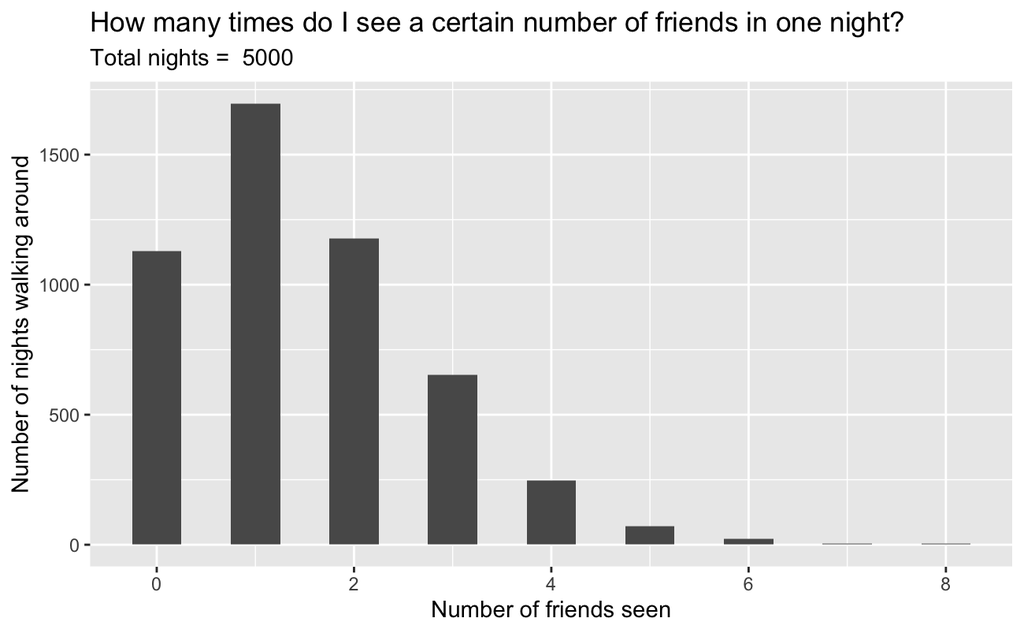

This plot shows that it is very unlikely to have a night like my Saturday night where I saw 8 of my close friends.

## Interpreting Results

- Why could this be?
- I have more friends than I estimated.
- I passed more people that night than I estimated.
- I am not actually passing random people.

# Thank you!

Back to the original website: https://starlight1114.github.io